# 研究课题：基于networkx的社区发现

```python
G = nx.read_gml(r'./data/football.gml')  # 获取社区划分
```

## 1. 一些评价指标

对modularity、NMI以及ARI三种常用评价方法进行介绍, 不同的计算方法有其适用场景和对应的优缺点。

### 1.1. 社区质量评估：网络模块度

模块度(Modularity)是复杂网络社区划分评价标准, 也是社区发现/社团检测(Community Detection)应用中用来衡量社区划分质量的一种方法。community包的modularity()实现了计算模块度功能，注意这里须再安装python-louvain包，因为community包中有其中相关的计算函数依赖

```python
def modularity(G, community):
    V = [node for node in G.nodes()]
    m = G.size(weight='weight')  # if weighted
    n = G.number_of_nodes()
    A = nx.to_numpy_array(G)
    Q = 0
    for i in range(n):
        node_i = V[i]
        com_i = community[node_i]
        degree_i = G.degree(node_i)
        for j in range(n):
            node_j = V[j]
            com_j = community[node_j]
            if com_i != com_j:
                continue
            degree_j = G.degree(node_j)
            Q += A[i][j] - degree_i * degree_j/(2 * m)
    return Q/(2 * m)
```

模块度得分很多时候也用如下的形式 $$ Q = \sum_{c=1}^k \Big[ \frac{l_c}{m} - \big( \frac{d_c}{2m} \big)^2 \Big],$$ 其中， $m$为网络中的总边数；$k$为社区个数，$l_c$为社区$c$内部的连接边数，$d_c$为社区$c$内所有节点的度之和。

```python
def Q(G, cur_community, real_community):
        """
        计算划分社区的模块度Q(modularity)
        未知和已知社区的评估指标
        :return: Q_value
        """
        nodes_number = self.G.number_of_nodes()
        edges_number = self.G.number_of_edges()
        Q_value = 0
        for key in self.cur_community.keys():
            #社区c
            c = self.cur_community[key]
            #社区内结点度数之和
            degrees = 0
            #社区内部边的总数
            inter_edges = 0
            for u in c:
                u_neighbors = set(nx.all_neighbors(self.G, u))
                degrees += len(u_neighbors)
                for nbr in u_neighbors:
                    if nbr in c:
                        inter_edges += 1
            #因为是无向图，所以边数要除以2
            inter_edges /= 2
            #cq = inter_edges / edges_number - math.pow(degrees / (2 * edges_number), 2)
            cq = inter_edges / edges_number - (degrees / (2 * edges_number)) ** 2
            Q_value += cq
        return Q_value
```

也可以使用Community.modularity()包计算模块度。

此外，图中所有节点的度分布情况，也是度量一张图复杂程度的一项指标，如下函数计算邻接矩阵所表示图的度

```python
def degree_matrix(G):
    n = G.number_of_nodes()
    V = [node for node in G.nodes()]
    D = np.zeros((n, n))
    for i in range(n):
        node = V[i]
        d_node = G.degree(node)
        D[i][i] = d_node
    return np.array(D)
```

### 1.2 标准化互信息社区质量评估方法

NMI（normalized mutual information）标准化互信息，也称为归一化互信息，是目前广泛使用的一种社区划分评价指标，用于度量算法所得到的社区和真实社区划分之间的相似程度，也用于评估聚类结果的相似程度，NMI的值域是0到1，越高代表划分得越准。其计算公式： $$ NMI(R,F) = \frac{-2\sum_{i=1}^{C_R}\sum_{j=1}^{C_F}N_{ij}\log(\frac{N_{ij}S}{N_{i*}N_{*j}})}{\sum^{C_R}N_{i*}\log(N_{i*}/S) + \sum^{C_F}N_{*j}\log(N_{*j}/S)} ,$$ 其中，矩阵$N$中的行表示真实的社区，列表示算法得到的社区；矩阵中第$i$行的元素表示为$N_{i∗}$,第$j$列的元素表示为$N_{∗j}$; $S$为节点个数；$N_{ij}$表示真实社区与算法所得到的社区相同的节点个数；$CR$表示真实社区个数，$CF$表示算法所得到的的社区个数。 当算法所得到的的社区划分与网络中的真实社区划分完全一致时，$NMI=1$; 两者完全独立时，$NMI=0$。

```python
def NMI(G, cur_community, real_community):
        """
        标准化互信息值( Normalized mutual information)
        已知真实社区划分结果的评价指标
        行代表真实社区划分（real_community）
        列代表当前社区划分结果(cur_community)
        :return:NMI_value
        """
        nodes_number = self.G.number_of_nodes()
        r_id = [key for key in self.real_community]
        c_id = [key for key in self.cur_community]
        #分子
        sum_rc = 0
        #分母两项之和
        sum_r = sum_c = 0

        for i in range(0, len(r_id)):
            temp = 0
            nodes_i = set(self.real_community[r_id[i]])
            for j in range(0, len(c_id)):
                nodes_j = set(self.cur_community[c_id[j]])
                common = nodes_i & nodes_j
                a = len(common) * nodes_number / (len(nodes_i) * len(nodes_j))
                if a > 0:
                    temp += len(common) * math.log10(a)
            sum_rc += temp

        for i in range(0, len(r_id)):
            nodes_i = set(self.real_community[r_id[i]])
            sum_r += len(nodes_i) * math.log10(len(nodes_i) / nodes_number)
        for j in range(0, len(c_id)):
            nodes_j = set(self.cur_community[c_id[j]])
            sum_c += len(nodes_j) * math.log10(len(nodes_j) / nodes_number)

        sum_rc = sum_rc * (-2)
        NMI_value = sum_rc / (sum_r + sum_c)
        return NMI_value
```

或

```python
def NMI(com, real_com):
    if len(com) != len(real_com):
        return ValueError('len(A) should be equal to len(B)')

    com = np.array(com)
    real_com = np.array(real_com)
    total = len(com)
    com_ids = set(com)
    real_com_ids = set(real_com)
    #Mutual information
    MI = 0
    eps = 1.4e-45
    for id_com in com_ids:
        for id_real in real_com_ids:
            idAOccur = np.where(com == id_com)
            idBOccur = np.where(real_com == id_real)
            idABOccur = np.intersect1d(idAOccur, idBOccur)
            px = 1.0*len(idAOccur[0])/total
            py = 1.0*len(idBOccur[0])/total
            pxy = 1.0*len(idABOccur)/total
            MI = MI + pxy*math.log(pxy/(px*py) + eps,2)
    # Normalized Mutual information
    Hx = 0
    for idA in com_ids:
        idAOccurCount = 1.0*len(np.where(com == idA)[0])
        Hx = Hx - (idAOccurCount/total)*math.log(idAOccurCount/total + eps, 2)
    Hy = 0
    for idB in real_com_ids:
        idBOccurCount = 1.0*len(np.where(real_com == idB)[0])
        Hy = Hy - (idBOccurCount/total) * math.log(idBOccurCount/total + eps, 2)
    MIhat = 2.0*MI/(Hx + Hy)
    return MIhat
```

```python
此外，也可以使用sklearn.metrics.normalized_mutual_info_score(labels_true, labels_pred)计算该得分。
```

### 1.3 兰德指数ARI（Adjusted Rand Index）社区评价算法

使用sklearn.metrics.adjusted_rand_score(labels_true, labels_pred)计算.参考 http://www.ai2news.com/blog/3041194/

```python
from sklearn import metrics
labels_true = [0, 0, 0, 1, 1, 1]
labels_pred = [0, 0, 1, 1, 2, 2]

# 基本用法
score = metrics.adjusted_rand_score(labels_true, labels_pred)
print(score)  # 0.24242424242424246

# 与标签名无关
labels_pred = [1, 1, 0, 0, 3, 3]
score = metrics.adjusted_rand_score(labels_true, labels_pred)
print(score)  # 0.24242424242424246

# 具有对称性
score = metrics.adjusted_rand_score(labels_pred, labels_true)
print(score)  # 0.24242424242424246

# 接近 1 最好
labels_pred = labels_true[:]
score = metrics.adjusted_rand_score(labels_true, labels_pred)
print(score)  # 1.0

# 独立标签结果为负或者接近 0
labels_true = [0, 1, 2, 0, 3, 4, 5, 1]
labels_pred = [1, 1, 0, 0, 2, 2, 2, 2]
score = metrics.adjusted_rand_score(labels_true, labels_pred)
print(score)  # -0.12903225806451613
```

不同的计算方法有其适用场景和对应的优缺点:

- ARI算法对任意数量的聚类中心和样本数，随机聚类的ARI都非常接近于0；取值在［－1，1］之间，负数代表结果不好，越接近于1越好，可用于聚类算法之间的比，但真实标签，也就是有监督数据。
- NMI需要真实标签数据，而模块度的方法最为直接，可以不需要有真实标签的数据，所以得到了广泛应用。

## 2. 计算实例

```python
import numpy as np
from matplotlib import pyplot as plt
```

案例:美国大学橄榄球联盟的比赛数据集(football)蕴含的网络划分为12个社区。 来源： https://github.com/qinyuenlp/CommunityDetection

```python
G = nx.read_gml(r'./data/football.gml')  # 获取社区划分， 计算量较大的请用netscience.gml
```

### 方案一：基于模块度的相似性计算

```python
import community.community_louvain as cm   # 须 pip install community 后再 pip install python-louvain
```

```python
def all_results(G):
    results = []
    m = G.number_of_edges()
    for i in range(m):
        betweenness_dict = nx.edge_betweenness_centrality(G)
        edge_max_betweenness = max(betweenness_dict.items(), key=lambda x:x[1])[0]
        G.remove_edge(edge_max_betweenness[0], edge_max_betweenness[1])
        community = [list(subgraph) for subgraph in nx.connected_components(G)]
        community_dict = {node:0 for node in G.nodes()}
        for i in range(len(community)):
            each = community[i]
            for node in each:
                community_dict[node] = i
        results.append(community_dict)
    return results
```

```python
import copy
```

```python
def partition_via_modulity(G):
    G_copy = copy.deepcopy(G)
    results = all_results(G)
    modularities = [cm.modularity(results[i], G_copy) for i in range(len(results))]
    max_modularity = max(modularities)
    max_index = modularities.index(max_modularity)
    max_result = results[max_index]
    return list(max_result.values()), max_modularity
```

```python
G_copy = copy.deepcopy(G)
```

```python
%%time
results = all_results(G)
```

```
CPU times: user 8.58 s, sys: 16 ms, total: 8.6 s
Wall time: 8.59 s
```

```python
modularities = [cm.modularity(results[i], G_copy) for i in range(len(results))]
```

```python
max_modularity = max(modularities)
max_index = modularities.index(max_modularity)
max_result = results[max_index]
gn_com = list(max_result.values())
```

[figure not shown]

```python
# 可视化1
pos = nx.spring_layout(G)
nx.draw(G, pos, with_labels=False, node_size=70, width=0.5, node_color=gn_com)
plt.show()
```

```python
V = [node for node in G.nodes()]
com_dict = {node:com for node, com in zip(V, gn_com)}
k = max(com_dict.values()) + 1
com = [[V[i] for i in range(G.number_of_nodes()) if gn_com[i] == j] for j in range(k)]
```

```python
# 构造可视化所需要的图
G_graph = nx.Graph()
for each in com:
  G_graph.update(nx.subgraph(G, each))  #
color = [com_dict[node] for node in G_graph.nodes()]
```

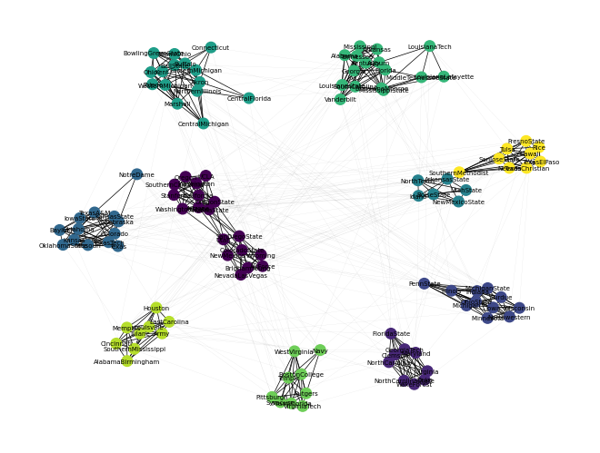

```python
# 可视化社区
pos = nx.spring_layout(G_graph, seed=4, k=0.33)
nx.draw(G, pos, with_labels=False, node_size=1, width=0.1, alpha=0.2)
nx.draw(G_graph, pos, with_labels=True, node_color=color, node_size=70, width=0.5, font_size=5, font_color='#000000')
plt.show()
```

### 方法二：谱聚类

```python
from sklearn.cluster import KMeans        # pip install scikit-learn
import scipy.linalg as linalg             # pip install scipy
```

```python
G = nx.read_gml(r'./data/polbooks.gml')  # 获取社区划分
```

基本聚类算法

```python
def SpectralClustering(G, k, normalized=False):
    A = nx.to_numpy_array(G)
    D = degree_matrix(G)
    L = D - A
    Dn = np.power(np.linalg.matrix_power(D, -1), 0.5)
    L = np.dot(np.dot(Dn, L), Dn)
    if normalized:
        pass
    eigvals, eigvecs = linalg.eig(L)
    n = len(eigvals)

    dict_eigvals = dict(zip(eigvals, range(0, n)))
    k_eigvals = np.sort(eigvals)[0:k]
    eigval_indexs = [dict_eigvals[k] for k in k_eigvals]
    k_eigvecs = eigvecs[:, eigval_indexs]
    result = KMeans(n_clusters=k, n_init=10).fit_predict(k_eigvecs)
    return result
```

```python
k = 12
sc_com = SpectralClustering(G, k)  # 谱聚类
print(sc_com)
```

[output not shown]

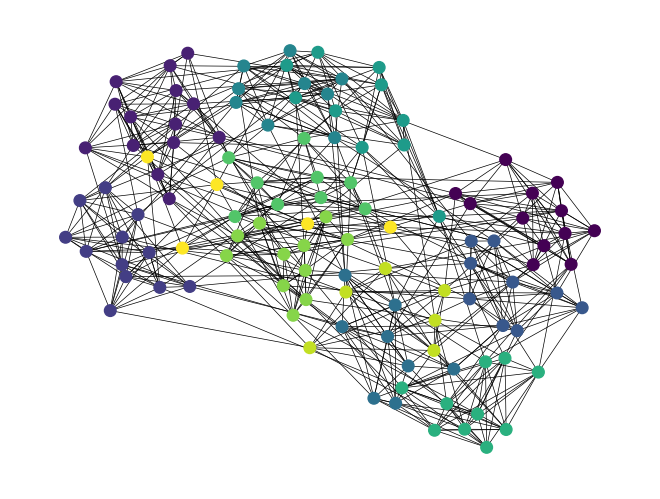

```python
# 可视化1
pos = nx.spring_layout(G)
nx.draw(G, pos, with_labels=False, node_size=70, width=0.5, node_color=sc_com)
plt.show()
```

```python
V = [node for node in G.nodes()]
com_dict = {node:com for node, com in zip(V, sc_com)}
com = [[V[i] for i in range(G.number_of_nodes()) if sc_com[i] == j] for j in range(k)]
```

```python
# 构造可视化所需要的图
G_graph = nx.Graph()
for each in com:
  G_graph.update(nx.subgraph(G, each))  #
color = [com_dict[node] for node in G_graph.nodes()]
```

[figure not shown]

```python
# 可视化社群
pos = nx.spring_layout(G_graph, seed=4, k=0.33)
nx.draw(G, pos, with_labels=False, node_size=1, width=0.1, alpha=0.2)
nx.draw(G_graph, pos, with_labels=True, node_color=color, node_size=70, width=0.5, font_size=5, font_color='#000000')
plt.show()
```

## 5. 流行病建模库EoN简介

基于ER网络和BA网络上的流行病仿真

### 5.1 基于ER均匀网络的仿真

```python
import EoN     # pip install EoN
```

```python
N = 10**4
M = 4*N
ER = nx.gnm_random_graph(N, M)   #
```

#### 5.1.1 SIS模型

```python
tau = 0.5          # transmission rate
gamma = 0.2     # recovery rate per node
t, S, I = EoN.fast_SIS(ER, tau=tau, gamma=gamma, tmax = 10)
```

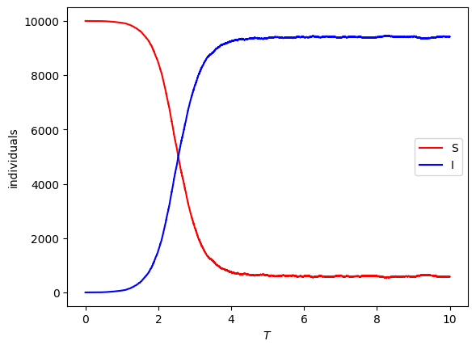

```python
plt.plot(t, S, color = 'r', label='S')
plt.plot(t, I, color = 'b', label='I')
plt.legend(loc=0)
plt.xlabel("$T$")
plt.ylabel("individuals")
```

#### 5.1.2 SIR模型

```python
tau = 0.5           # transmission rate
gamma = 1.0    # recovery rate
rho = 0.05      # random fraction initially infected
```

```python
t, S, I, R = EoN.fast_SIR(ER, tau, gamma, rho=rho, tmax = 20)
```

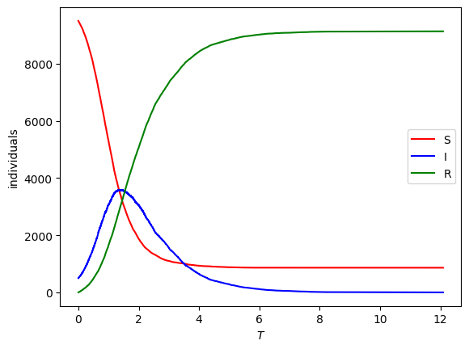

```python
plt.plot(t, S, color = 'r', label='S')
plt.plot(t, I, color = 'b', label='I')
plt.plot(t, R, color = 'g', label='R')
plt.legend(loc=0)
plt.xlabel("$T$")
plt.ylabel("individuals")
```

### 5.2 基于BA异质网络的仿真

#### 5.2.1 SIS模型

```python
N = 10**4
BA= nx.barabasi_albert_graph(N, 4) #create a barabasi-albert graph
```

```python
t, S, I = EoN.fast_SIS(BA, tau=0.5, gamma=0.05, tmax = 10)
```

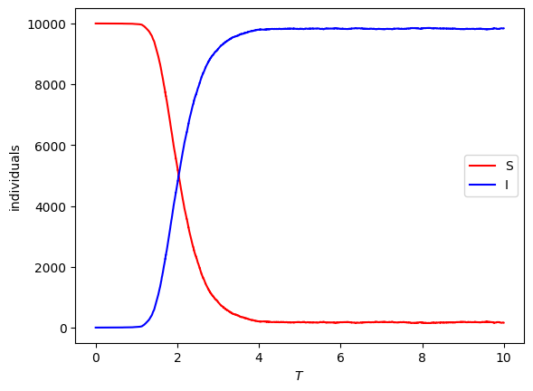

```python
plt.plot(t, S, color = 'r', label='S')
plt.plot(t, I, color = 'b', label='I')
plt.legend(loc=0)
plt.xlabel("$T$")
plt.ylabel("individuals")
```

#### 5.2.2 SIR模型

```python
t, S, I, R = EoN.fast_SIR(BA, tau = 0.5, gamma = 1.0, rho = 0.05, tmax = 10)
```

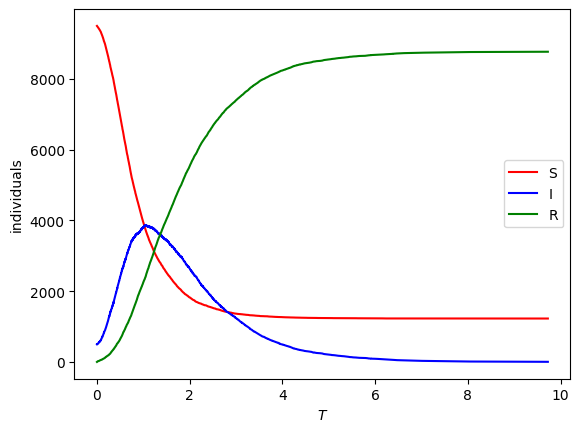

```python
plt.plot(t, S, color = 'r', label='S')
plt.plot(t, I, color = 'b', label='I')
plt.plot(t, R, color = 'g', label='R')
plt.legend(loc=0)
plt.xlabel("$T$")
plt.ylabel("individuals")
```